# Assignment_1

### From the corrplot() diagram the interaction between ‘displacement’ and ‘cylinder’ , ‘weight’ and displacement’, ‘horsepower’ and ‘displacement’ also ‘weight’ and ‘cylinder’ looked promising.

```r
model_2 <- lm(mpg ~ . -name +displacement*cylinders  , data = Auto)
summary(model_2)
```

```
##
## Call:
## lm(formula = mpg ~ . - name + displacement * cylinders, data = Auto)
##
## Residuals:
##      Min       1Q   Median       3Q      Max
## -11.6081  -1.7833  -0.0465   1.6821  12.2617
##
## Coefficients:
##                          Estimate Std. Error t value Pr(>|t|)
## (Intercept)            -2.7096590  4.6858582  -0.578 0.563426
## cylinders              -2.6962123  0.4094916  -6.584 1.51e-10 ***
## displacement           -0.0774797  0.0141535  -5.474 7.96e-08 ***
## horsepower             -0.0476026  0.0133736  -3.559 0.000418 ***
## weight                 -0.0052339  0.0006253  -8.370 1.10e-15 ***
## acceleration            0.0597997  0.0918038   0.651 0.515188
## year                    0.7594500  0.0473354  16.044  < 2e-16 ***
## origin                  0.7087399  0.2736917   2.590 0.009976 **
## cylinders:displacement  0.0136081  0.0017209   7.907 2.84e-14 ***
## ---
## Signif. codes:  0 '***' 0.001 '**' 0.01 '*' 0.05 '.' 0.1 ' ' 1
##
## Residual standard error: 3.089 on 383 degrees of freedom
## Multiple R-squared:  0.8465, Adjusted R-squared:  0.8433
## F-statistic: 264.1 on 8 and 383 DF,  p-value: < 2.2e-16
```

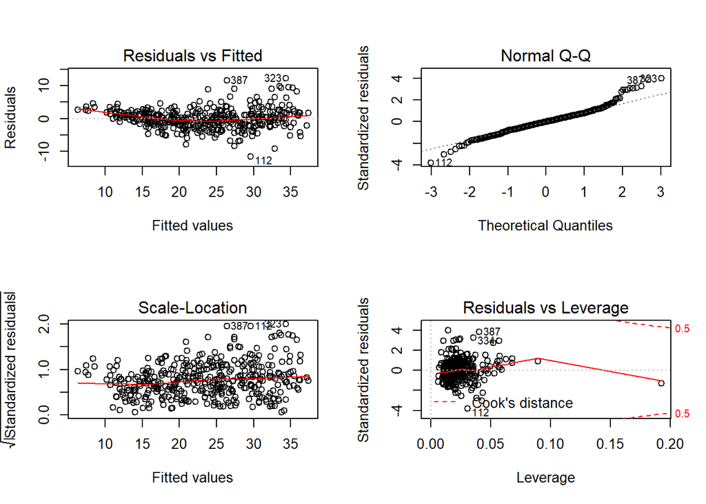

```r
par(mfrow = c(2,2))
plot(model_2)
```

```r
model_3 <- lm(mpg ~ . -name +weight*displacement , data = Auto)
summary(model_3)
```

```
##
## Call:
## lm(formula = mpg ~ . - name + weight * displacement, data = Auto)
##
## Residuals:
##     Min      1Q  Median      3Q     Max
## -9.9027 -1.8092 -0.0946  1.5549 12.1687
##
## Coefficients:
##                       Estimate Std. Error t value Pr(>|t|)
## (Intercept)         -5.389e+00  4.301e+00  -1.253   0.2109
## cylinders            1.175e-01  2.943e-01   0.399   0.6899
## displacement        -6.837e-02  1.104e-02  -6.193 1.52e-09 ***
## horsepower          -3.280e-02  1.238e-02  -2.649   0.0084 **
## weight              -1.064e-02  7.136e-04 -14.915  < 2e-16 ***
## acceleration         6.724e-02  8.805e-02   0.764   0.4455
## year                 7.852e-01  4.553e-02  17.246  < 2e-16 ***
## origin               5.610e-01  2.622e-01   2.139   0.0331 *
## displacement:weight  2.269e-05  2.257e-06  10.054  < 2e-16 ***
## ---
## Signif. codes:  0 '***' 0.001 '**' 0.01 '*' 0.05 '.' 0.1 ' ' 1
##
## Residual standard error: 2.964 on 383 degrees of freedom
## Multiple R-squared:  0.8588, Adjusted R-squared:  0.8558
## F-statistic: 291.1 on 8 and 383 DF,  p-value: < 2.2e-16
```

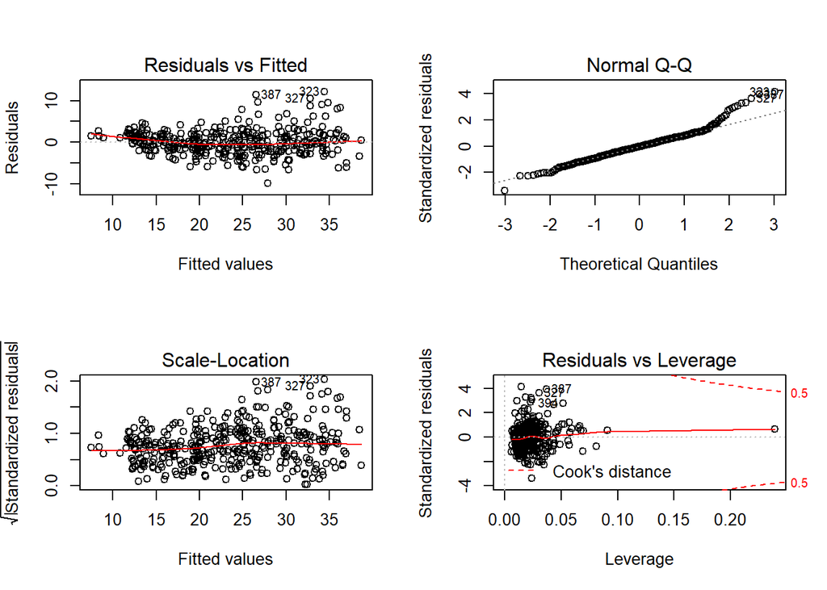

```r
plot(model_3)
```

```r
model_4 <- lm(mpg ~ . -name +displacement*horsepower , data = Auto)
summary(model_4)
```

```
##
## Call:
## lm(formula = mpg ~ . - name + displacement * horsepower, data = Auto)
##
## Residuals:
##     Min      1Q  Median      3Q     Max
## -8.7010 -1.6009 -0.0967  1.4119 12.6734
##
## Coefficients:
##                           Estimate Std. Error t value Pr(>|t|)
## (Intercept)             -1.894e+00  4.302e+00  -0.440  0.66007
## cylinders                6.466e-01  3.017e-01   2.143  0.03275 *
## displacement            -7.487e-02  1.092e-02  -6.859 2.80e-11 ***
## horsepower              -1.975e-01  2.052e-02  -9.624  < 2e-16 ***
## weight                  -3.147e-03  6.475e-04  -4.861 1.71e-06 ***
## acceleration            -2.131e-01  9.062e-02  -2.351  0.01921 *
## year                     7.379e-01  4.463e-02  16.534  < 2e-16 ***
## origin                   6.891e-01  2.527e-01   2.727  0.00668 **
## displacement:horsepower  5.236e-04  4.813e-05  10.878  < 2e-16 ***
## ---
## Signif. codes:  0 '***' 0.001 '**' 0.01 '*' 0.05 '.' 0.1 ' ' 1
##
## Residual standard error: 2.912 on 383 degrees of freedom
## Multiple R-squared:  0.8636, Adjusted R-squared:  0.8608
## F-statistic: 303.1 on 8 and 383 DF,  p-value: < 2.2e-16
```

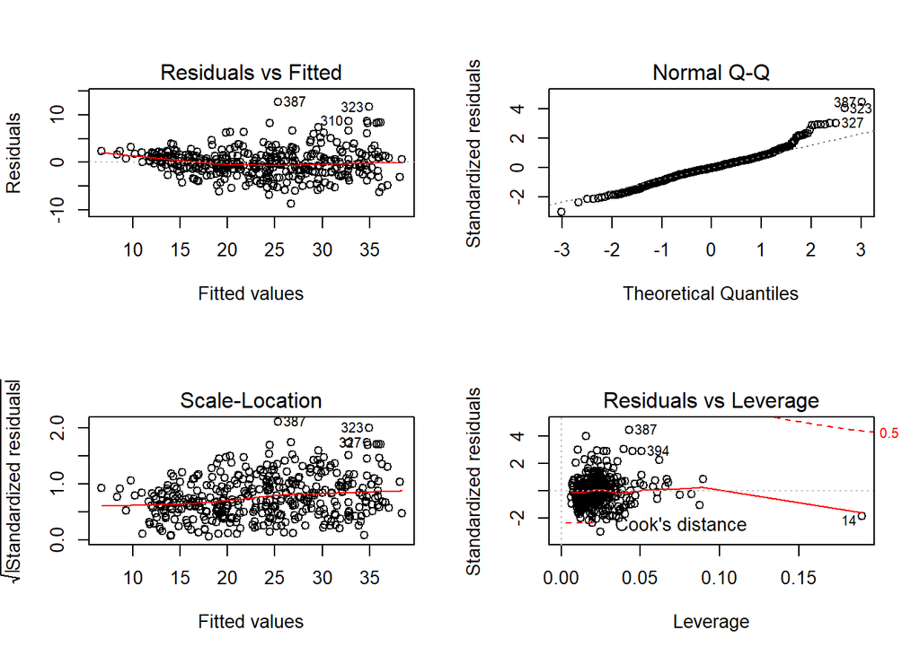

```r
plot(model_4)
```

```r
model_5 <- lm(mpg ~ . -name +weight*cylinders , data = Auto)
summary(model_5)
```

```
##
## Call:
## lm(formula = mpg ~ . - name + weight * cylinders, data = Auto)
##
## Residuals:
##      Min       1Q   Median       3Q      Max
## -10.9484  -1.7133  -0.1809   1.4530  12.4137
##
## Coefficients:
##                    Estimate Std. Error t value Pr(>|t|)
## (Intercept)       7.3143478  5.0076737   1.461  0.14494
## cylinders        -5.0347425  0.5795767  -8.687  < 2e-16 ***
## displacement      0.0156444  0.0068409   2.287  0.02275 *
## horsepower       -0.0314213  0.0126216  -2.489  0.01322 *
## weight           -0.0150329  0.0011125 -13.513  < 2e-16 ***
## acceleration      0.1006438  0.0897944   1.121  0.26306
## year              0.7813453  0.0464139  16.834  < 2e-16 ***
## origin            0.8030154  0.2617333   3.068  0.00231 **
## cylinders:weight  0.0015058  0.0001657   9.088  < 2e-16 ***
## ---
## Signif. codes:  0 '***' 0.001 '**' 0.01 '*' 0.05 '.' 0.1 ' ' 1
##
## Residual standard error: 3.022 on 383 degrees of freedom
## Multiple R-squared:  0.8531, Adjusted R-squared:  0.8501
## F-statistic: 278.1 on 8 and 383 DF,  p-value: < 2.2e-16
```

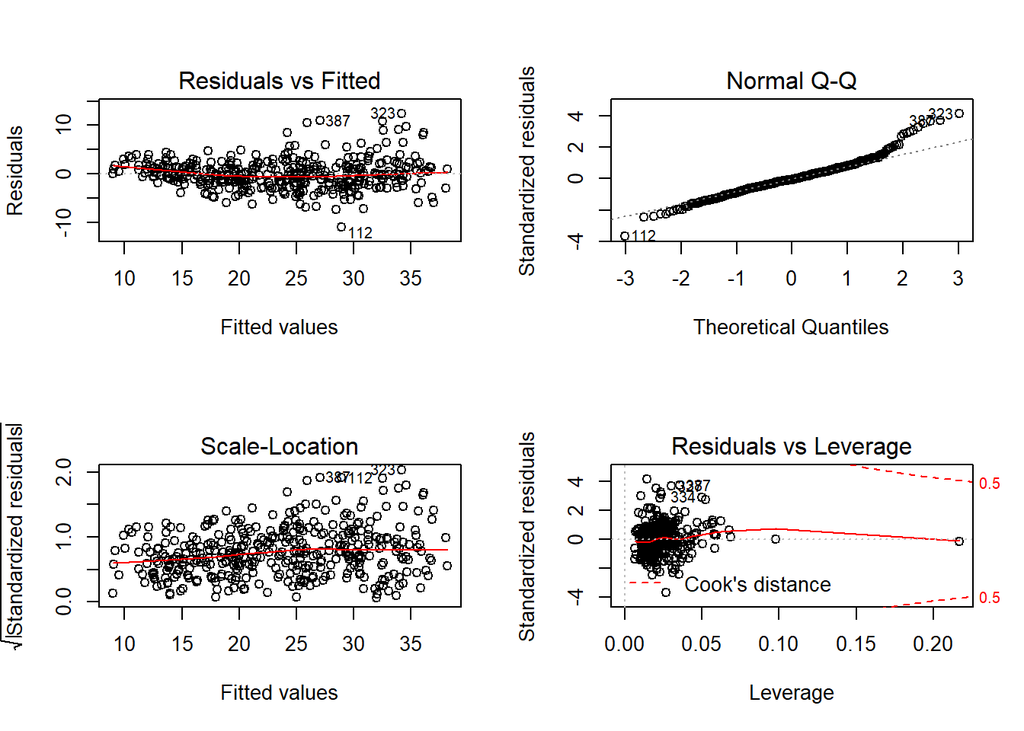

```r
plot(model_5)
```

```r
model_6 <- lm(mpg ~ . -name -displacement  +weight*cylinders  +acceleration*horsepower +year*origin , data = Auto)
summary(model_6)
```

```
##
## Call:
## lm(formula = mpg ~ . - name - displacement + weight * cylinders +
##     acceleration * horsepower + year * origin, data = Auto)
##
## Residuals:
##     Min      1Q  Median      3Q     Max
## -9.6053 -1.7809  0.0271  1.4749 12.2039
##
## Coefficients:
##                           Estimate Std. Error t value Pr(>|t|)
## (Intercept)              1.418e+01  8.947e+00   1.585  0.11375
## cylinders               -4.260e+00  5.388e-01  -7.907 2.87e-14 ***
## horsepower               6.477e-02  1.976e-02   3.278  0.00114 **
## weight                  -1.243e-02  1.121e-03 -11.090  < 2e-16 ***
## acceleration             7.087e-01  1.412e-01   5.019 7.97e-07 ***
## year                     5.292e-01  9.874e-02   5.359 1.45e-07 ***
## origin                  -1.117e+01  4.116e+00  -2.713  0.00697 **
## cylinders:weight         1.323e-03  1.615e-04   8.190 3.95e-15 ***
## horsepower:acceleration -7.998e-03  1.471e-03  -5.437 9.70e-08 ***
## year:origin              1.523e-01  5.301e-02   2.874  0.00428 **
## ---
## Signif. codes:  0 '***' 0.001 '**' 0.01 '*' 0.05 '.' 0.1 ' ' 1
##
## Residual standard error: 2.882 on 382 degrees of freedom
## Multiple R-squared:  0.8668, Adjusted R-squared:  0.8636
## F-statistic: 276.1 on 9 and 382 DF,  p-value: < 2.2e-16
```

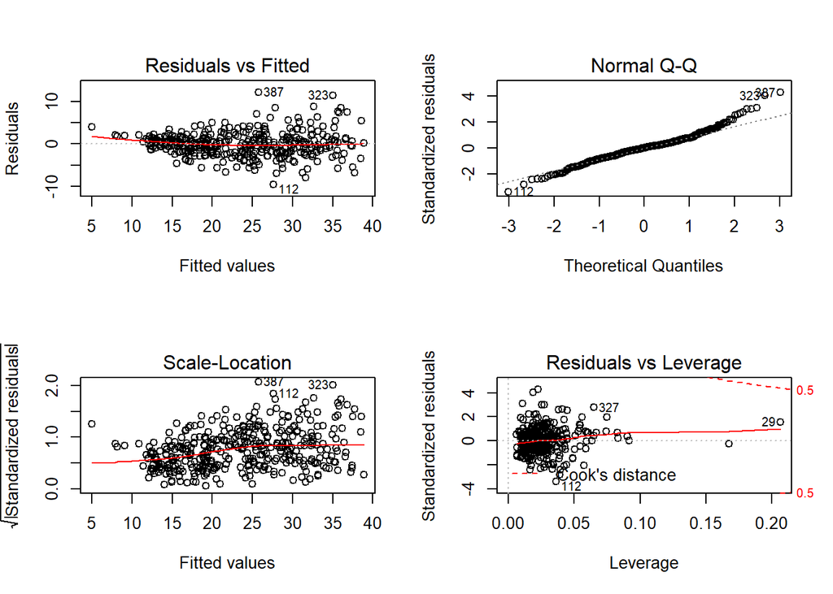

```r
plot(model_6)
```

### (f)

```r
model_t1 <- lm(mpg ~ . -name -cylinders -displacement +log(weight) + sqrt(acceleration) + I(horsepower^2) , data = Auto)
summary(model_t1)
```

```
##
## Call:
## lm(formula = mpg ~ . - name - cylinders - displacement + log(weight) +
##     sqrt(acceleration) + I(horsepower^2), data = Auto)
##
## Residuals:
##     Min      1Q  Median      3Q     Max
## -9.1958 -1.5816 -0.0691  1.3643 12.3421
##
## Coefficients:
##                      Estimate Std. Error t value Pr(>|t|)
## (Intercept)         2.528e+02  4.203e+01   6.015 4.21e-09 ***
## horsepower         -1.661e-01  3.952e-02  -4.203 3.28e-05 ***
## weight              5.662e-03  1.681e-03   3.368 0.000835 ***
## acceleration        3.092e+00  9.533e-01   3.244 0.001284 **
## year                7.860e-01  4.454e-02  17.649  < 2e-16 ***
## origin              7.427e-01  2.353e-01   3.156 0.001725 **
## log(weight)        -3.013e+01  5.349e+00  -5.633 3.43e-08 ***
## sqrt(acceleration) -2.632e+01  7.591e+00  -3.467 0.000586 ***
## I(horsepower^2)     4.310e-04  1.289e-04   3.344 0.000907 ***
## ---
## Signif. codes:  0 '***' 0.001 '**' 0.01 '*' 0.05 '.' 0.1 ' ' 1
##
## Residual standard error: 2.873 on 383 degrees of freedom
## Multiple R-squared:  0.8673, Adjusted R-squared:  0.8645
## F-statistic: 312.8 on 8 and 383 DF,  p-value: < 2.2e-16
```

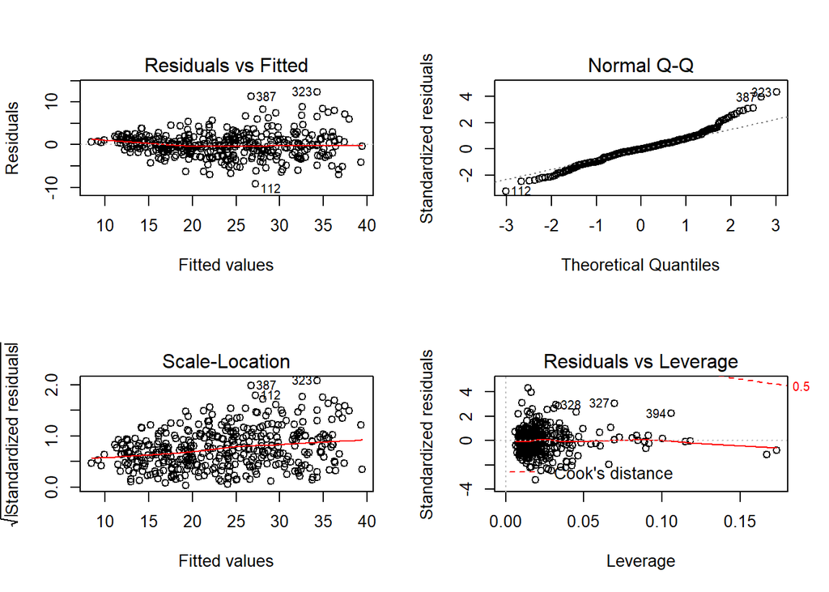

```r
par(mfrow=c(2,2))
plot(model_t1)
```

```r
model_t2 <- lm(mpg ~ . -name  +log(weight) + sqrt(horsepower) + I(displacement^2) , data = Auto)
summary(model_t2)
```

```
##
## Call:
## lm(formula = mpg ~ . - name + log(weight) + sqrt(horsepower) +
##     I(displacement^2), data = Auto)
##
## Residuals:
##     Min      1Q  Median      3Q     Max
## -9.2561 -1.5050 -0.1086  1.4238 11.9557
##
## Coefficients:
##                     Estimate Std. Error t value Pr(>|t|)
## (Intercept)        1.228e+02  4.375e+01   2.806  0.00527 **
## cylinders          2.067e-01  3.362e-01   0.615  0.53917
## displacement      -3.685e-02  1.989e-02  -1.853  0.06469 .
## horsepower         2.207e-01  6.595e-02   3.346  0.00090 ***
## weight             1.154e-03  2.051e-03   0.563  0.57395
## acceleration      -2.032e-01  1.002e-01  -2.029  0.04317 *
## year               7.651e-01  4.508e-02  16.972  < 2e-16 ***
## origin             5.522e-01  2.662e-01   2.074  0.03875 *
## log(weight)       -1.486e+01  6.666e+00  -2.229  0.02638 *
## sqrt(horsepower)  -6.022e+00  1.469e+00  -4.100 5.05e-05 ***
## I(displacement^2)  6.646e-05  3.434e-05   1.936  0.05366 .
## ---
## Signif. codes:  0 '***' 0.001 '**' 0.01 '*' 0.05 '.' 0.1 ' ' 1
##
## Residual standard error: 2.9 on 381 degrees of freedom
## Multiple R-squared:  0.8654, Adjusted R-squared:  0.8619
## F-statistic:   245 on 10 and 381 DF,  p-value: < 2.2e-16
```

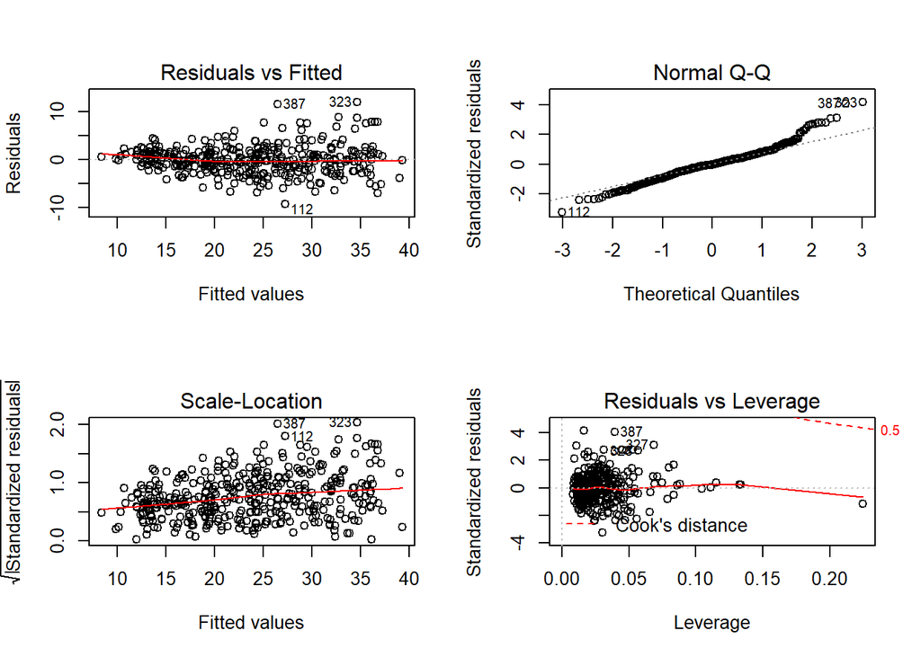

```r
plot(model_t2)
```

```r
model_t3 <- lm(mpg ~ . -name -displacement  +log(horsepower) + sqrt(weight) + I(acceleration^2) , data = Auto)
summary(model_t3)
```

```
##
## Call:
## lm(formula = mpg ~ . - name - displacement + log(horsepower) +
##     sqrt(weight) + I(acceleration^2), data = Auto)
##
## Residuals:
##     Min      1Q  Median      3Q     Max
## -9.4147 -1.5129 -0.0617  1.4274 12.4734
##
## Coefficients:
##                     Estimate Std. Error t value Pr(>|t|)
## (Intercept)        99.013541  10.672364   9.278  < 2e-16 ***
## cylinders          -0.221330   0.210331  -1.052 0.293330
## horsepower          0.049076   0.031145   1.576 0.115911
## weight              0.014873   0.003844   3.869 0.000129 ***
## acceleration       -1.958676   0.543050  -3.607 0.000351 ***
## year                0.782981   0.044503  17.594  < 2e-16 ***
## origin              0.672190   0.237763   2.827 0.004944 **
## log(horsepower)   -11.578913   3.755570  -3.083 0.002197 **
## sqrt(weight)       -2.112418   0.437326  -4.830 1.98e-06 ***
## I(acceleration^2)   0.053679   0.016405   3.272 0.001165 **
## ---
## Signif. codes:  0 '***' 0.001 '**' 0.01 '*' 0.05 '.' 0.1 ' ' 1
##
## Residual standard error: 2.868 on 382 degrees of freedom
## Multiple R-squared:  0.8681, Adjusted R-squared:  0.865
## F-statistic: 279.3 on 9 and 382 DF,  p-value: < 2.2e-16
```

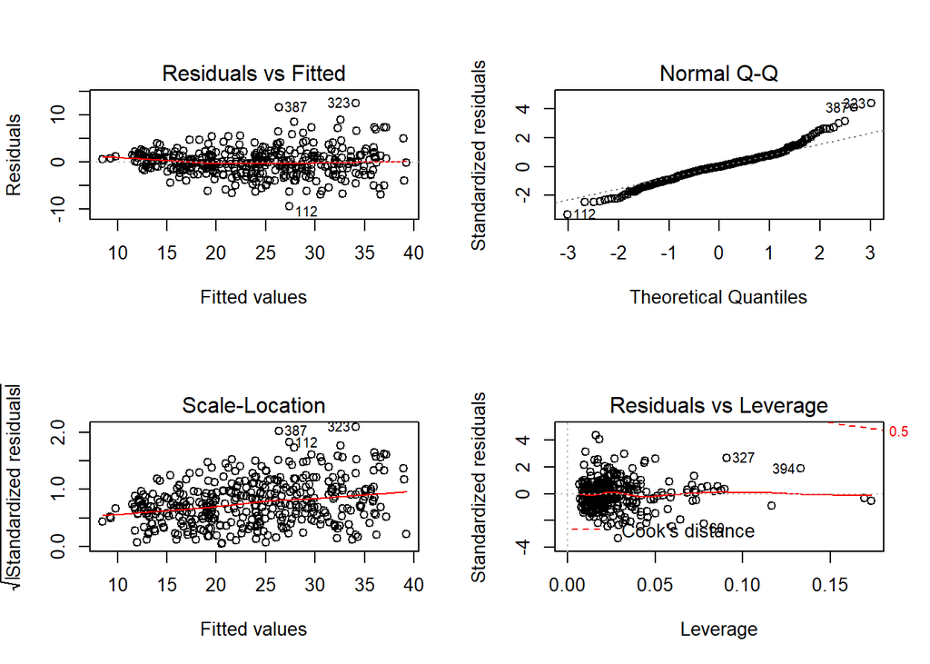

```r
plot(model_t3)
```

### Also from the residual graphs it is known that this linear model is good fit for relatively small x values, but is not a good predictor of larger x values. The distribution of the residuals is quite well concentrated around 0 for small fitted values, but they get more and more spread out as the fitted values increase.This is an instance of “increasing variance”. The standard linear regression assumption is that the variance is constant across the entire range. When this assumption isn’t valid, such as in this example, we shouldn’t believe our confidence intervals, prediction bands, or the p-values in our regression.